# Black-throated Blue Warblers

Karina Johnston

12/1/2021

```r
knitr::opts_chunk$set(echo = TRUE, warning = FALSE, message = FALSE)

# Attach packages
library(tidyverse)
library(here)
library(naniar)
library(broom)
library(GGally)
library(kableExtra)
library(modelsummary)
library(equatiomatic)
library(texreg)
```

```r
# Read in the data

warblers <- read_csv(here("data", "bt_warblers.csv")) %>%

# replace values of -99.99 in all columns with NA using naniar
  replace_with_na(warblers, replace = list(bill_depth = -99.99,
                                           bill_culmen = -99.99,
                                           mass = -99.99,
                                           tarsus1 = -99.99,
                                           wing_r = -99.99))
```

### Introduction

This report explored relationships of body measurements and encounter histories of black-throated blue warblers from Hubbard Brook Experimental Forest from 1986 - 2010 (Rodenhouse et al. 2019). These data were gathered as part of the Hubbard Brook Ecosystem Study.

Exploratory plots were created to evaluate the relationships between continuous variables, then multiple linear regression was used to explore the relationship between warbler mass (dependent variable) and other explanatory variables.

### Exploratory Analyses

In this section, exploratory visualization graphs are created to view the data variables. The first is a faceted scatter plot of wing length (mm) versus bird mass (g), separated by sex and wrapped by age at capture (banding). The second is a scatter plot of tarsus length (mm) versus mass (g), separated by sex and faceted for elevation (location of sample plot). The third graph is a violin plot of mass separated by sex and age, and the fourth graph explores bill depth (mm) versus bill culmen length (mm). Lastly, the `ggpairs()` function is used to explore multiple relationships together for selected variables on a pairs plot.

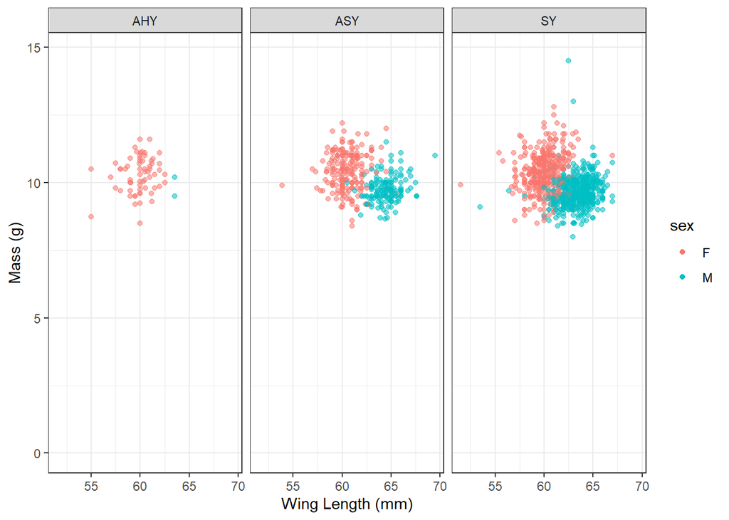

```r
# Create exploratory graphs to visualize the data

# first graph - wing length vs mass
ggplot(data = warblers, aes(x = wing_r,
                            y = mass)) + # plot wing length vs mass
  geom_point(aes(color = sex,
                 alpha = 0.5)) + # geometry scatterplot colored by sex
  facet_wrap(~ age_banded) + # facet wrap by age
  theme_bw() + # cleaner visualized theme
  labs(x = "Wing Length (mm)",
       y = "Mass (g)") + # easier to interpret labels
  guides(alpha = FALSE) # removes unnecessary legend
```

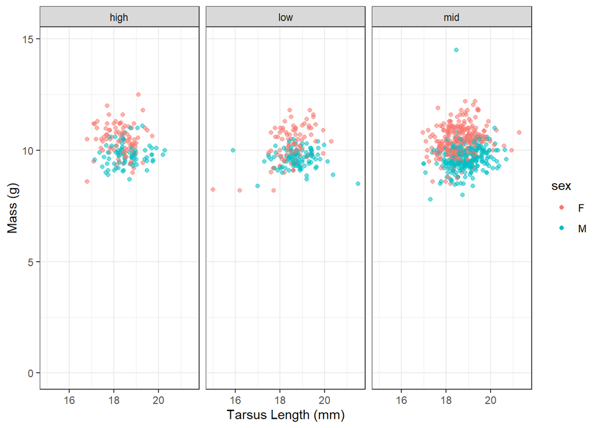

```r
# second graph - tarsus length versus mass
ggplot(data = warblers, aes(x = tarsus1,
                            y = mass)) + # plot tarsus length vs mass
  geom_point(aes(color = sex,
                 alpha = 0.5)) + # geometry scatterplot colored by sex
  facet_wrap(~ elevation) + # facet wrap by elevation
  theme_bw() + # cleaner visualized theme
  labs(x = "Tarsus Length (mm)",
       y = "Mass (g)") + # easier to interpret labels
  guides(alpha = FALSE) # removes unnecessary legend
```

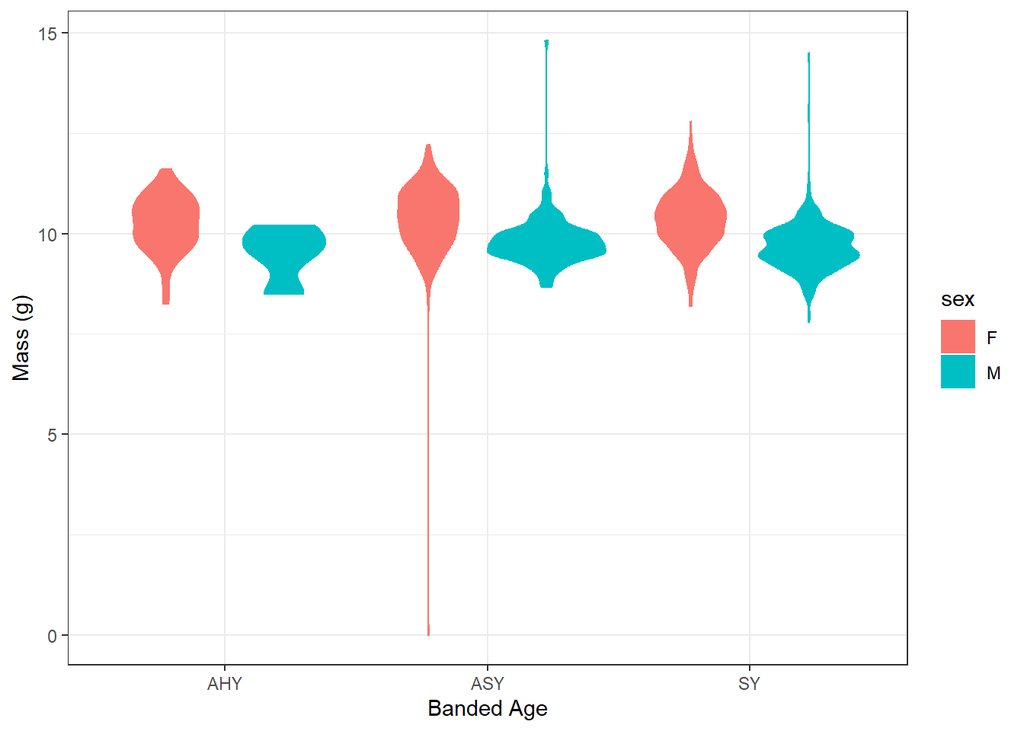

```r
# third graph - violin plot of mass separated by sex and age
ggplot(data = warblers, aes(x = age_banded,
                            y = mass)) +
  geom_violin(aes(color = sex, # geometry violin colored by sex
                  fill = sex)) +
  theme_bw() + # cleaner visualized theme
  labs(x = "Banded Age", # easier to interpret labels
       y = "Mass (g)")
```

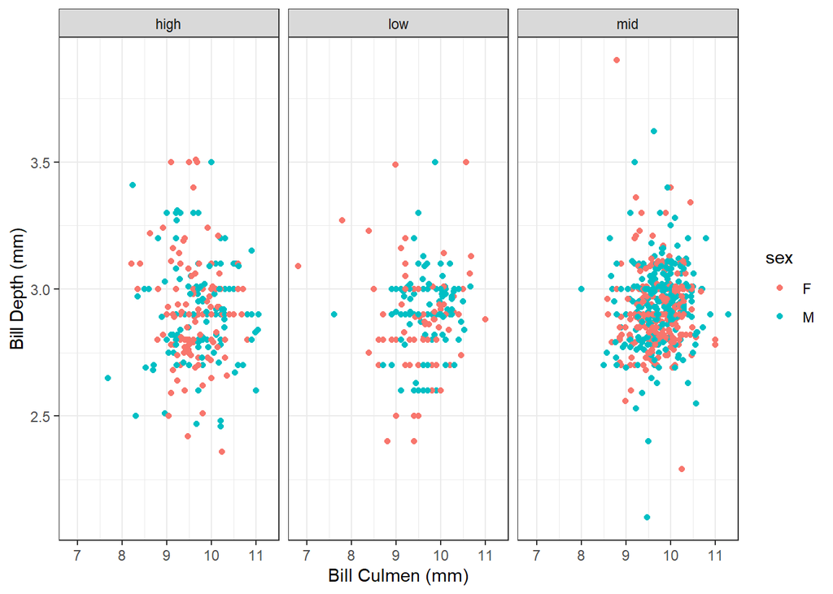

```r
# fourth graph - bill depth versus bill culmen
ggplot(data = warblers, aes(x = bill_culmen, y = bill_depth)) +
  geom_point(aes(color = sex)) + # scatterplot geometry colored by sex
  facet_wrap(~ elevation) + # facet wrap by elevation
  theme_bw() + # cleaner visualized theme
  labs(x = "Bill Culmen (mm)", # easier to interpret labels
       y = "Bill Depth (mm)")
```

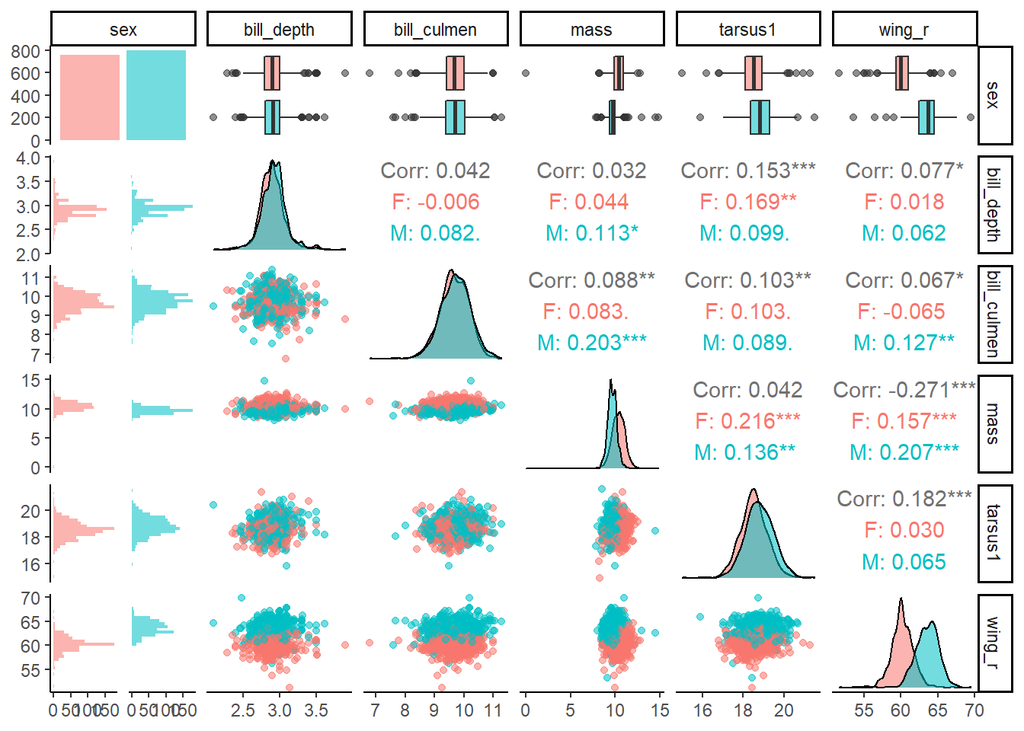

```r
# Use GGally::ggpairs() function to create pairs plot for full exploration

warblers %>%
  select(sex, bill_depth:wing_r) %>% # select the variables
  ggpairs(aes(color = sex,
              alpha = 0.5)) + # increase the transparency for better viewing
  theme_classic() # cleaner to interpret
```

### Data Analyses - Multiple Linear Regression

Table 1 displays a finalized multiple linear regression model using black-throated blue warbler mass as the dependent variable. Eight multiple linear regression models were evaluated for best fit.

```r
# Finalized regression table

caption <- "Table 1. Finalized warbler multiple linear regression model using bird mass (g) as the dependent variable (Data: Rodenhouse et al. 2019)."

final_table <- modelsummary(list(warblers_lm8), # create a new df for the final table
                            output = "kableExtra",
                            title = caption,
                            stars = TRUE, # adds stars for the p-value

                            # renames the coefficients to be more meaningful
                            coef_rename = c("(Intercept)" = "Intercept",
                                            "wing_r" = "Right Wing Length (mm)",
                                            "tarsus1" = "Tarsus Length (mm)",
                                            "bill_culmen" = "Bill Length (mm)",
                                            "sexM" = "Sex (Male)")
                            )

final_table # output the table
```

Table 1. Finalized warbler multiple linear regression model using bird mass (g) as the dependent variable (Data: Rodenhouse et al. 2019).

|  | Model 1 |
| --- | --- |
| Intercept | 3.623** |
|  | (1.137) |
| Right Wing Length (mm) | 0.071*** |
|  | (0.015) |
| Tarsus Length (mm) | 0.065+ |
|  | (0.033) |
| Bill Length (mm) | 0.140** |
|  | (0.047) |
| Sex (Male) | -1.031*** |
|  | (0.068) |
| Num.Obs. | 669 |
| R2 | 0.330 |
| R2 Adj. | 0.326 |
| AIC | 1193.9 |
| BIC | 1220.9 |
| Log.Lik. | -590.933 |
| F | 81.616 |

+ p < 0.1, * p < 0.05, ** p < 0.01, *** p < 0.001

The final multiple linear regression model selected is presented in Equation 1:

```r
# Use equatiomatic to output the selected regression model

extract_eq(model = warblers_lm8, use_coefs = TRUE)
```

$$\operatorname{\widehat{mass}} = 3.62 + 0.07(\operatorname{wing\_r}) + 0.07(\operatorname{tarsus1}) + 0.14(\operatorname{bill\_culmen}) - 1.03(\operatorname{sex}_{\operatorname{M}})$$

Regression model coefficient interpretation:

- If everything else is constant, on average for every 1 mm increase in wing length, we expect warbler body mass to increase by 0.071 grams.
- If everything else is constant, on average for every 1 mm increase in tarsus length, we expect warbler body mass to increase by 0.065 grams.
- If everything else is constant, on average for every 1 mm increase in bill length, we expect warbler body mass to increase by 0.14 grams.
- If everything else is constant, on average we expect the male warblers to have a mass -1.031 grams less than the female warblers (female is the reference level in this model).

### Citations

R Core Team (2021). R: A language and environment for statistical computing. R Foundation for Statistical Computing, Vienna, Austria. URL https://www.R-project.org/.

Robinson, David, Alex Hayes and Simon Couch (2021). broom: Convert Statistical Objects into Tidy Tibbles. R package version 0.7.10. https://CRAN.R-project.org/package=broom

Rodenhouse, N., R. Holmes, S. Sillett, and M. Webster. 2019. Black-throated Blue Warbler capture histories, Hubbard Brook Experimental Forest, 1986 - 2010 ver 4. Environmental Data Initiative. https://doi.org/10.6073/pasta/ea985022acfdb76cd7beeaf8da6c39b1

Schloerke, Barret, Di Cook, Joseph Larmarange, Francois Briatte, Moritz Marbach, Edwin Thoen, Amos Elberg and Jason Crowley (2021). GGally: Extension to ‘ggplot2’. R package version 2.1.2. https://CRAN.R-project.org/package=GGally

Tierney, Nicholas, Di Cook, Miles McBain and Colin Fay (2021). naniar: Data Structures, Summaries, and Visualizations for Missing Data. R package version 0.6.1. https://CRAN.R-project.org/package=naniar

Wickham, H. et al., (2019). Welcome to the tidyverse. Journal of Open Source Software, 4(43), 1686, https://doi.org/10.21105/joss.01686

Zhu, H. (2021). kableExtra: Construct Complex Table with ‘kable’ and Pipe Syntax. R package version 1.3.4. https://CRAN.R-project.org/package=kableExtra